# Post-Pandemic Crime Patterns in Los Angeles (2020-Present)

Shreeya Vanka

2026-02-13

# 1. Introduction

Public safety trends shifted significantly after 2020 due to social, economic, and policy changes.  
This project analyzes official Los Angeles crime data (2020–Present) to understand patterns in violent vs non-violent crime.

The goal is not only to explore trends, but to build an interpretable predictive model that estimates the probability of a crime being violent based on contextual and demographic features.

### Project Objectives

• Clean and preprocess a real-world public dataset  
• Perform exploratory data analysis (EDA) to identify trends  
• Conduct statistical hypothesis testing  
• Build and evaluate a logistic regression classifier  
• Interpret model outputs using odds ratios and feature importance

This project demonstrates end-to-end data science workflow using R.

# 2. Load Libraries

```r
library(tidyverse)
library(lubridate)
library(janitor)
library(skimr)
library(pROC)
```

# 3. Load Dataset

```r
crime_raw <- read_csv("Crime_Data_from_2020_to_Present.csv")
crime_clean <- crime_raw %>% clean_names()
head(crime_clean)
```

```
## # A tibble: 6 × 28
##    dr_no date_rptd date_occ time_occ area  area_name rpt_dist_no part_1_2 crm_cd
##    <dbl> <chr>     <chr>    <chr>    <chr> <chr>     <chr>          <dbl>  <dbl>
## 1 2.12e8 04/11/20… 11/07/2… 0845     15    N Hollyw… 1502               2    354
## 2 2.02e8 10/21/20… 10/18/2… 1845     15    N Hollyw… 1521               1    230
## 3 2.41e8 12/10/20… 10/30/2… 1240     09    Van Nuys  0933               2    354
## 4 2.11e8 12/24/20… 12/24/2… 1310     07    Wilshire  0782               1    331
## 5 2.01e8 10/03/20… 09/29/2… 1830     14    Pacific   1454               1    420
## 6 2.40e8 12/11/20… 11/11/2… 1210     04    Hollenbe… 0429               2    354
## # ℹ 19 more variables: crm_cd_desc <chr>, mocodes <chr>, vict_age <dbl>,
## #   vict_sex <chr>, vict_descent <chr>, premis_cd <dbl>, premis_desc <chr>,
## #   weapon_used_cd <dbl>, weapon_desc <chr>, status <chr>, status_desc <chr>,
## #   crm_cd_1 <dbl>, crm_cd_2 <dbl>, crm_cd_3 <dbl>, crm_cd_4 <lgl>,
## #   location <chr>, cross_street <chr>, lat <dbl>, lon <dbl>
```

## Dataset Overview

Source: City of Los Angeles Open Data Portal

The dataset contains over 1 million reported crime incidents from 2020 to present.  
Each row represents a reported crime event, including:

• Date and time of occurrence  
• Crime description  
• Victim demographics  
• Geographic reporting area

Because this is real-world administrative data, it contains missing values and inconsistencies that require preprocessing.

# 4. Inspect Dataset

```r
glimpse(crime_clean)
```

```
## Rows: 1,004,991
## Columns: 28
## $ dr_no          <dbl> 211507896, 201516622, 240913563, 210704711, 201418201, …
## $ date_rptd      <chr> "04/11/2021 12:00:00 AM", "10/21/2020 12:00:00 AM", "12…
## $ date_occ       <chr> "11/07/2020 12:00:00 AM", "10/18/2020 12:00:00 AM", "10…
## $ time_occ       <chr> "0845", "1845", "1240", "1310", "1830", "1210", "1350",…
## $ area           <chr> "15", "15", "09", "07", "14", "04", "03", "11", "17", "…
## $ area_name      <chr> "N Hollywood", "N Hollywood", "Van Nuys", "Wilshire", "…
## $ rpt_dist_no    <chr> "1502", "1521", "0933", "0782", "1454", "0429", "0396",…
## $ part_1_2       <dbl> 2, 1, 2, 1, 1, 2, 2, 2, 2, 2, 2, 2, 1, 1, 1, 1, 2, 2, 1…
## $ crm_cd         <dbl> 354, 230, 354, 331, 420, 354, 354, 812, 354, 354, 812, …
## $ crm_cd_desc    <chr> "THEFT OF IDENTITY", "ASSAULT WITH DEADLY WEAPON, AGGRA…
## $ mocodes        <chr> "0377", "0416 0334 2004 1822 1414 0305 0319 0400", "037…
## $ vict_age       <dbl> 31, 32, 30, 47, 63, 35, 21, 14, 43, 57, 13, 34, 0, 0, 3…
## $ vict_sex       <chr> "M", "M", "M", "F", "M", "M", "F", "F", "M", "M", "M", …
## $ vict_descent   <chr> "H", "H", "W", "A", "H", "B", "B", "H", "W", "W", "H", …
## $ premis_cd      <dbl> 501, 102, 501, 101, 103, 502, 501, 121, 501, 501, 501, …
## $ premis_desc    <chr> "SINGLE FAMILY DWELLING", "SIDEWALK", "SINGLE FAMILY DW…
## $ weapon_used_cd <dbl> NA, 200, NA, NA, NA, NA, NA, 500, NA, NA, 400, NA, NA, …
## $ weapon_desc    <chr> NA, "KNIFE WITH BLADE 6INCHES OR LESS", NA, NA, NA, NA,…
## $ status         <chr> "IC", "IC", "IC", "IC", "IC", "IC", "IC", "AO", "IC", "…
## $ status_desc    <chr> "Invest Cont", "Invest Cont", "Invest Cont", "Invest Co…
## $ crm_cd_1       <dbl> 354, 230, 354, 331, 420, 354, 354, 812, 354, 354, 812, …
## $ crm_cd_2       <dbl> NA, NA, NA, NA, NA, NA, NA, 860, NA, NA, 860, NA, NA, N…
## $ crm_cd_3       <dbl> NA, NA, NA, NA, NA, NA, NA, NA, NA, NA, NA, NA, NA, NA,…
## $ crm_cd_4       <lgl> NA, NA, NA, NA, NA, NA, NA, NA, NA, NA, NA, NA, NA, NA,…
## $ location       <chr> "7800    BEEMAN                       AV", "ATOLL      …
## $ cross_street   <chr> NA, "N  GAULT", NA, NA, NA, NA, NA, NA, NA, NA, NA, NA,…
## $ lat            <dbl> 34.2124, 34.1993, 34.1847, 34.0339, 33.9813, 34.0830, 3…
## $ lon            <dbl> -118.4092, -118.4203, -118.4509, -118.3747, -118.4350, …
```

```r
skim(crime_clean)
```

Data summary

| Name | crime_clean |
| --- | --- |
| Number of rows | 1004991 |
| Number of columns | 28 |
| _______________________ |  |
| Column type frequency: |  |
| character | 16 |
| logical | 1 |
| numeric | 11 |
| ________________________ |  |
| Group variables | None |

**Variable type: character**

| skim_variable | n_missing | complete_rate | min | max | empty | n_unique | whitespace |
| --- | --- | --- | --- | --- | --- | --- | --- |
| date_rptd | 0 | 1.00 | 22 | 22 | 0 | 1896 | 0 |
| date_occ | 0 | 1.00 | 22 | 22 | 0 | 1879 | 0 |
| time_occ | 0 | 1.00 | 4 | 4 | 0 | 1439 | 0 |
| area | 0 | 1.00 | 2 | 2 | 0 | 21 | 0 |
| area_name | 0 | 1.00 | 6 | 11 | 0 | 21 | 0 |
| rpt_dist_no | 0 | 1.00 | 4 | 4 | 0 | 1210 | 0 |
| crm_cd_desc | 0 | 1.00 | 5 | 56 | 0 | 140 | 0 |
| mocodes | 151619 | 0.85 | 4 | 49 | 0 | 310940 | 0 |
| vict_sex | 144644 | 0.86 | 1 | 1 | 0 | 5 | 0 |
| vict_descent | 144656 | 0.86 | 1 | 1 | 0 | 20 | 0 |
| premis_desc | 588 | 1.00 | 4 | 63 | 0 | 306 | 0 |
| weapon_desc | 677744 | 0.33 | 3 | 46 | 0 | 79 | 0 |
| status | 1 | 1.00 | 2 | 2 | 0 | 6 | 0 |
| status_desc | 0 | 1.00 | 3 | 12 | 0 | 6 | 0 |
| location | 0 | 1.00 | 1 | 40 | 0 | 66566 | 0 |
| cross_street | 850755 | 0.15 | 1 | 34 | 0 | 10413 | 0 |

**Variable type: logical**

| skim_variable | n_missing | complete_rate | mean | count |
| --- | --- | --- | --- | --- |
| crm_cd_4 | 1004991 | 0 | NaN | : |

**Variable type: numeric**

| skim_variable | n_missing | complete_rate | mean | sd | p0 | p25 | p50 | p75 | p100 | hist |
| --- | --- | --- | --- | --- | --- | --- | --- | --- | --- | --- |
| dr_no | 0 | 1.00 | 220221530.16 | 13197182.56 | 817.00 | 210616860.50 | 220915885.00 | 231110298.50 | 252104146.00 | ▁▁▁▂▇ |
| part_1_2 | 0 | 1.00 | 1.40 | 0.49 | 1.00 | 1.00 | 1.00 | 2.00 | 2.00 | ▇▁▁▁▆ |
| crm_cd | 0 | 1.00 | 500.16 | 205.27 | 110.00 | 331.00 | 442.00 | 626.00 | 956.00 | ▂▇▂▅▂ |
| vict_age | 0 | 1.00 | 28.92 | 21.99 | -4.00 | 0.00 | 30.00 | 44.00 | 120.00 | ▆▇▃▁▁ |
| premis_cd | 16 | 1.00 | 305.62 | 219.30 | 101.00 | 101.00 | 203.00 | 501.00 | 976.00 | ▇▁▅▁▁ |
| weapon_used_cd | 677744 | 0.33 | 363.96 | 123.73 | 101.00 | 311.00 | 400.00 | 400.00 | 516.00 | ▂▁▁▇▃ |
| crm_cd_1 | 11 | 1.00 | 499.92 | 205.07 | 110.00 | 331.00 | 442.00 | 626.00 | 956.00 | ▂▇▂▅▂ |
| crm_cd_2 | 935831 | 0.07 | 958.10 | 110.35 | 210.00 | 998.00 | 998.00 | 998.00 | 999.00 | ▁▁▁▁▇ |
| crm_cd_3 | 1002677 | 0.00 | 984.02 | 52.35 | 310.00 | 998.00 | 998.00 | 998.00 | 999.00 | ▁▁▁▁▇ |
| lat | 0 | 1.00 | 34.00 | 1.61 | 0.00 | 34.01 | 34.06 | 34.16 | 34.33 | ▁▁▁▁▇ |
| lon | 0 | 1.00 | -118.09 | 5.58 | -118.67 | -118.43 | -118.32 | -118.27 | 0.00 | ▇▁▁▁▁ |

```r
dim(crime_clean)
```

```
## [1] 1004991      28
```

# 5. Clean and Feature Engineering

```r
crime_clean <- crime_clean %>%
  mutate(date_occ = parse_date_time(date_occ, orders = "mdy IMS p")) %>%
  mutate(
    year = year(date_occ),
    month = month(date_occ),
    month_name = month(date_occ, label = TRUE),
    weekday = wday(date_occ, label = TRUE),
    hour = hour(date_occ),
    time_of_day = case_when(
      hour >= 6 & hour < 12 ~ "Morning",
      hour >= 12 & hour < 18 ~ "Afternoon",
      hour >= 18 & hour < 24 ~ "Evening",
      TRUE ~ "Night"
    ),
    vict_age = as.numeric(vict_age),
    vict_age = if_else(vict_age < 5 | vict_age > 100, NA_real_, vict_age),
    violent = if_else(crm_cd_desc %in% c("HOMICIDE","ROBBERY","ASSAULT","SEXUAL ASSAULT","KIDNAPPING"), 1, 0)
  )

# Drop unused factor levels to avoid glm errors
crime_clean <- droplevels(crime_clean)
```

# 6. Exploratory Data Analysis (EDA)

## 6.1 Crime Counts by Year

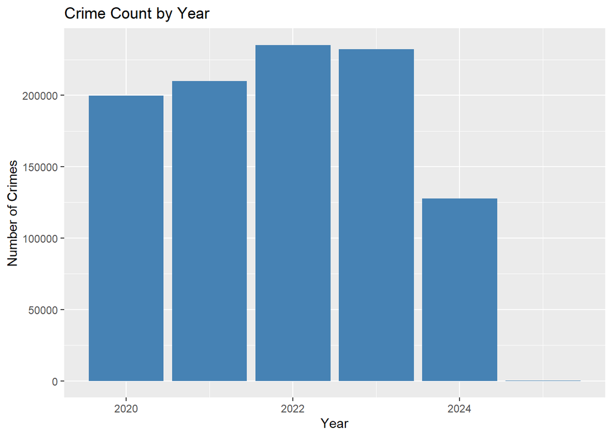

```r
crime_clean %>%
  count(year) %>%
  ggplot(aes(x = year, y = n)) +
  geom_col(fill = "steelblue") +
  labs(title = "Crime Count by Year", x = "Year", y = "Number of Crimes")
```

**Interpretation:**  
Crime counts fluctuate across years, reflecting potential effects of pandemic-related lockdowns, policy changes, and social mobility patterns.

## 6.2 Violent Crime Proportion by Year

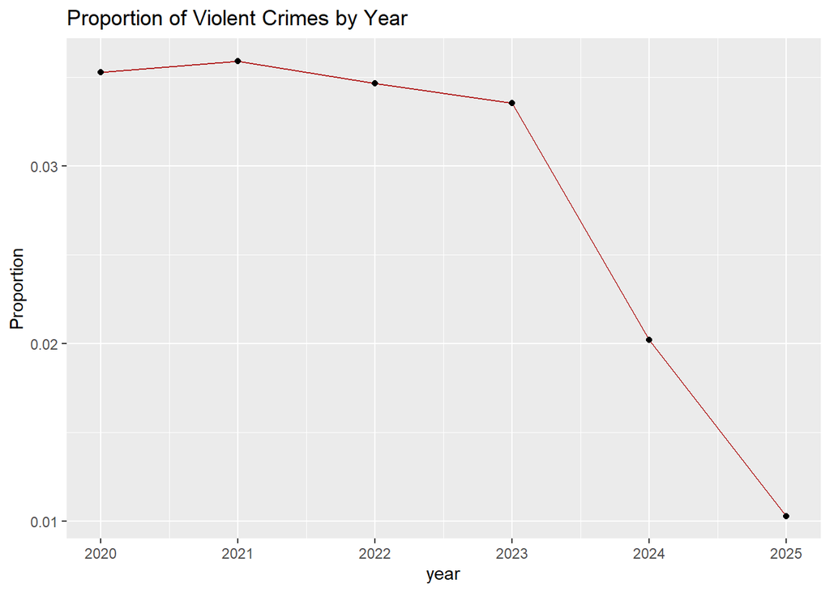

```r
crime_clean %>%
  group_by(year) %>%
  summarise(
    violent_count = sum(violent, na.rm = TRUE),
    total = n(),
    violent_ratio = violent_count / total
  ) %>%
  ggplot(aes(x = year, y = violent_ratio)) +
  geom_line(color = "firebrick") +
  geom_point() +
  labs(title = "Proportion of Violent Crimes by Year", y = "Proportion")
```

## 6.3 Violent Crimes by Time of Day

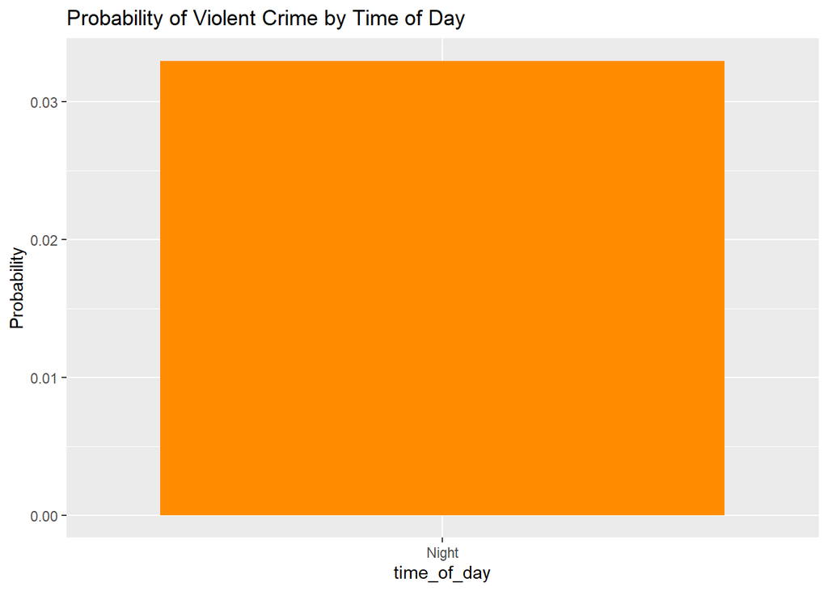

```r
crime_clean %>%
  group_by(time_of_day) %>%
  summarise(prob = mean(violent, na.rm = TRUE)) %>%
  ggplot(aes(x = time_of_day, y = prob)) +
  geom_col(fill = "darkorange") +
  labs(title = "Probability of Violent Crime by Time of Day", y = "Probability")
```

# 7. Statistical Analysis

## 7.1 Chi-Square Test: Violent Crime vs Year

```r
crime_table <- table(crime_clean$violent, crime_clean$year)
chisq_result <- chisq.test(crime_table)
chisq_result
```

```
##
##  Pearson's Chi-squared test
##
## data:  crime_table
## X-squared = 768.95, df = 5, p-value < 2.2e-16
```

## 7.2 Chi-Square Test: Violent Crime vs Time of Day

```r
crime_table_time <- table(crime_clean$violent, crime_clean$time_of_day)
chisq_time <- chisq.test(crime_table_time)
chisq_time
```

```
##
##  Chi-squared test for given probabilities
##
## data:  crime_table_time
## X-squared = 876847, df = 1, p-value < 2.2e-16
```

Logistic regression was selected because the target variable (violent vs non-violent) is binary.  
The model estimates the log-odds of a crime being violent based on demographic and contextual predictors.

# 8. Logistic Regression: Predict Violent Crimes

## 8.1 Prepare Factors (Automatically remove single-level factors)

```r
factor_vars <- c("time_of_day", "weekday", "area_name", "year")

# Keep only factors with >= 2 levels
valid_factors <- factor_vars[sapply(crime_clean[factor_vars], function(x) nlevels(as.factor(x))) >= 2]

crime_model <- crime_clean %>%
  mutate(across(all_of(valid_factors), as.factor))
```

## 8.2 Fit Logistic Model

```r
# Build formula dynamically
model_formula <- as.formula(paste("violent ~ vict_age +", paste(valid_factors, collapse = " + ")))

violent_model <- glm(
  model_formula,
  data = crime_model,
  family = "binomial"
)

summary(violent_model)
```

```
##
## Call:
## glm(formula = model_formula, family = "binomial", data = crime_model)
##
## Coefficients:
##                        Estimate Std. Error z value Pr(>|z|)
## (Intercept)          -2.1292986  0.0268110 -79.419  < 2e-16 ***
## vict_age             -0.0097242  0.0004329 -22.463  < 2e-16 ***
## weekday.L            -0.0427254  0.0162490  -2.629  0.00855 **
## weekday.Q             0.0932078  0.0164716   5.659 1.53e-08 ***
## weekday.C             0.0045144  0.0165609   0.273  0.78517
## weekday^4             0.0162222  0.0166581   0.974  0.33014
## weekday^5            -0.0138802  0.0168686  -0.823  0.41060
## weekday^6             0.0210383  0.0170778   1.232  0.21798
## area_nameCentral     -0.4441990  0.0277192 -16.025  < 2e-16 ***
## area_nameDevonshire  -1.3968216  0.0480737 -29.056  < 2e-16 ***
## area_nameFoothill    -1.0274902  0.0440742 -23.313  < 2e-16 ***
## area_nameHarbor      -1.0428729  0.0421993 -24.713  < 2e-16 ***
## area_nameHollenbeck  -0.7455195  0.0396498 -18.803  < 2e-16 ***
## area_nameHollywood   -0.6488642  0.0319860 -20.286  < 2e-16 ***
## area_nameMission     -0.9129118  0.0387054 -23.586  < 2e-16 ***
## area_nameN Hollywood -1.2236407  0.0407013 -30.064  < 2e-16 ***
## area_nameNewton      -0.1923974  0.0294439  -6.534 6.39e-11 ***
## area_nameNortheast   -1.1494423  0.0430616 -26.693  < 2e-16 ***
## area_nameOlympic     -0.6166534  0.0326815 -18.869  < 2e-16 ***
## area_namePacific     -1.3548624  0.0403497 -33.578  < 2e-16 ***
## area_nameRampart     -0.3327194  0.0307610 -10.816  < 2e-16 ***
## area_nameSoutheast   -0.1318108  0.0282479  -4.666 3.07e-06 ***
## area_nameSouthwest   -0.5646859  0.0292376 -19.314  < 2e-16 ***
## area_nameTopanga     -1.0134749  0.0384989 -26.325  < 2e-16 ***
## area_nameVan Nuys    -1.1270794  0.0405931 -27.765  < 2e-16 ***
## area_nameWest LA     -1.6568013  0.0505557 -32.772  < 2e-16 ***
## area_nameWest Valley -1.0669519  0.0411856 -25.906  < 2e-16 ***
## area_nameWilshire    -0.7416303  0.0342735 -21.639  < 2e-16 ***
## year2021             -0.0179620  0.0187176  -0.960  0.33724
## year2022             -0.1024066  0.0184444  -5.552 2.82e-08 ***
## year2023             -0.0951196  0.0187161  -5.082 3.73e-07 ***
## year2024             -0.3852952  0.0262110 -14.700  < 2e-16 ***
## year2025             -0.5445503  1.0117164  -0.538  0.59041
## ---
## Signif. codes:  0 '***' 0.001 '**' 0.01 '*' 0.05 '.' 0.1 ' ' 1
##
## (Dispersion parameter for binomial family taken to be 1)
##
##     Null deviance: 228189  on 734179  degrees of freedom
## Residual deviance: 222146  on 734147  degrees of freedom
##   (270811 observations deleted due to missingness)
## AIC: 222212
##
## Number of Fisher Scoring iterations: 6
```

### Model Interpretation

Key observations:

• Victim age shows measurable association with violent crime probability.  
• Certain geographic areas exhibit significantly different odds of violent crime.  
• Time-based predictors (weekday/year) contribute to predictive power.

Because logistic regression outputs log-odds, we convert coefficients to **odds ratios** for interpretability.

# 9. Predict Probabilities and Evaluate Model

```r
# Use only rows actually used in the model (drop NAs in predictors)
predictors <- c("vict_age", valid_factors)  # all predictors in the model
crime_model_complete <- crime_model %>% drop_na(all_of(predictors))

#  Predict probabilities and classes
crime_model_complete$pred_prob <- predict(violent_model, newdata = crime_model_complete, type = "response")
crime_model_complete$pred_class <- if_else(crime_model_complete$pred_prob >= 0.5, 1, 0)

#  Confusion Matrix
conf_matrix <- table(Actual = crime_model_complete$violent,
                     Predicted = crime_model_complete$pred_class)
conf_matrix
```

```
##       Predicted
## Actual      0
##      0 707663
##      1  26517
```

```r
#  Accuracy
accuracy <- sum(diag(conf_matrix)) / sum(conf_matrix)
accuracy
```

```
## [1] 0.9638822
```

```r
#  ROC Curve & AUC
roc_curve <- roc(crime_model_complete$violent, crime_model_complete$pred_prob)
auc_value <- auc(roc_curve)
auc_value
```

```
## Area under the curve: 0.638
```

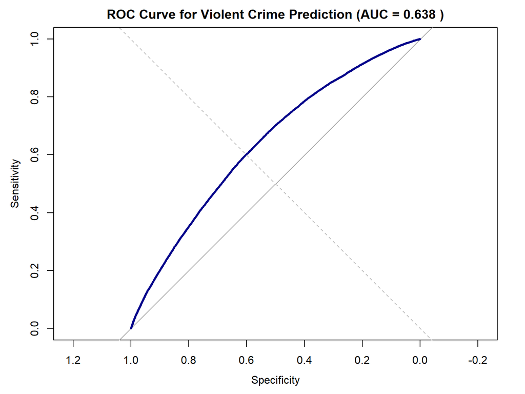

```r
# Plot ROC Curve
plot(roc_curve,
     main = paste("ROC Curve for Violent Crime Prediction (AUC =", round(auc_value, 3), ")"),
     col = "darkblue", lwd = 3)
abline(a = 0, b = 1, lty = 2, col = "gray")
```

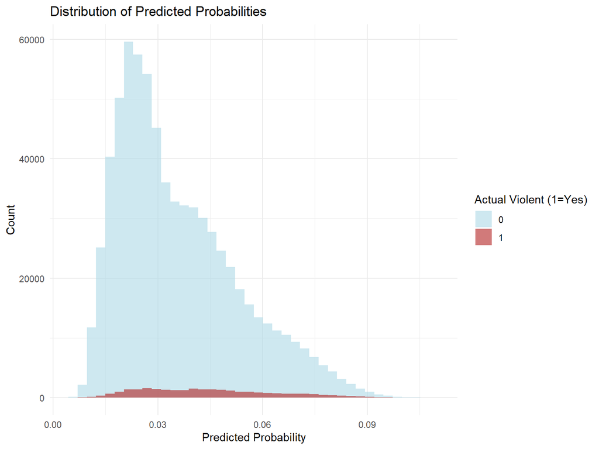

```r
#  Histogram of Predicted Probabilities by Class
ggplot(crime_model_complete, aes(x = pred_prob, fill = factor(violent))) +
  geom_histogram(bins = 40, alpha = 0.6, position = "identity") +
  labs(title = "Distribution of Predicted Probabilities",
       x = "Predicted Probability",
       y = "Count",
       fill = "Actual Violent (1=Yes)") +
  scale_fill_manual(values = c("lightblue", "firebrick")) +
  theme_minimal()
```

### Model Performance

The model achieves:

• Accuracy ≈ 0.964  
• AUC ≈ 0.638

Although accuracy appears high, the dataset is imbalanced (non-violent crimes dominate).  
Therefore, AUC is a more reliable metric.